# Simulation of Ventilator Allocation Strategies During the COVID-19 Pandemic

Siva Bhavani, Dwight Miller, Lainie Ross, Susan Han, Monica Malec, Mark Siegler, William Parker

# Simulation using CDC data

## CDC data source

The age of the simulated patients are sampled from the age distribution of COVID-19-infected patients as reported by the Centers for Disease Control We took data from the CDC report [Severe Outcomes Among Patients with Coronavirus Disease 2019 — United States, February 12–March 16, 2020](https://www.cdc.gov/mmwr/volumes/69/wr/mm6912e2.htm?s_cid=mm6912e2_w)

## Calibration of the SOFA score

The [Sequential Organ Failure Assesment (SOFA) score](https://en.wikipedia.org/wiki/SOFA_score) is a validated bedside predictor of ICU mortality. The calibration of SOFA scores is drawn from [*Raith et al. JAMA, 2017*](https://jamanetwork.com/journals/jama/fullarticle/2598267)

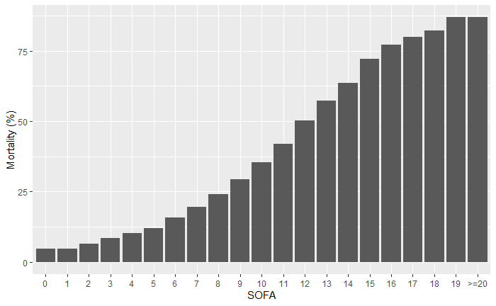

## Simulated ICU population from CDC data distribution

The relationship between age, comorbidities and SOFA score were derived from a large tertiary care hospital system. The comorbidity burden was categorized as none, major or severe based on a combination of currently utilized priority scores and the value of the AHRQ Elixhauser Co-morbidity Index Score for in-hospital mortality. The comorbidity burden was regressed on the age of the patients, and the SOFA score was regressed on the age and comorbidity burden of the patients. These relationships between age, comorbidity burden and SOFA were used to simulate patient data for the study.

## Example simulation

### Age score distribution

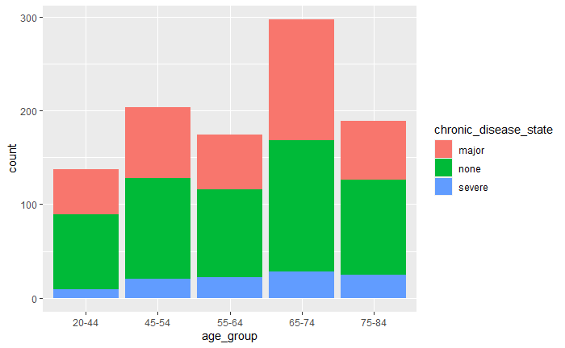

| age_group | mean_sofa |
| --- | --- |
| 20-44 | 7.627737 |
| 45-54 | 7.911330 |
| 55-64 | 7.982759 |
| 65-74 | 8.026936 |
| 75-84 | 8.074074 |

### SOFA score distribution

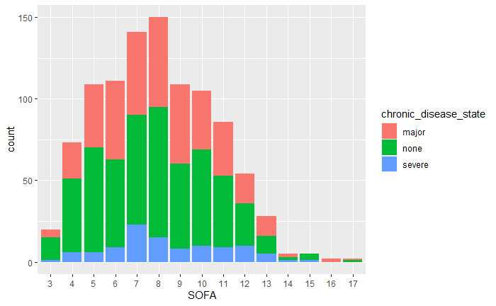

$f(SOFA |age)$Currently drawn from a truncated normal distribution with lower limit $a = 3$, upper limit $b = 20$, $\mu = 7 + 0.006*age$, and $\sigma = 2.95$. Parameters of the condititional SOFA and chronic disease distribution estimated from the clinical status at intubation of a [large cohort of patients with suspected infections](https://pubmed.ncbi.nlm.nih.gov/27649072/)

### SOFA Score by Age

| Age | Mean SOFA | Survival with Ventilator |
| --- | --- | --- |
| 20-44 | 7.6 | 75% |
| 45-54 | 7.9 | 74% |
| 55-64 | 8.0 | 74% |
| 65-74 | 8.0 | 73% |
| 75-84 | 8.1 | 73% |

## Run 10,000 simulations and save results

# Applying triage rules to the samples

Now I apply various triage rules under conditions of 50% ventilator scarcity. The specific utilitarian performance metrics of these rules are **lives saved** and **life-years saved**. The first goal is to maximize lives saved by giving as many people who will survive with mechanical ventilation access to a mechancial ventilator

$$Lives \space saved = \sum_i (1-y_i)*I\{vent=yes\}$$

Another important ethical consideration is the number of **life-years** saved

$$LifeYears \space saved = \sum_i (1-y_i)*(lifeYears \space remaing)*I\{vent=yes\}$$
Where each survivor allocated a ventilator is weighted by the maximum number of remaining life-years. Some utilitarians would optimize this quantity over lives-saved.

The number of life-years remaining depens on the patient’s chronic disease state:

$$lifeYears \space remaining | no \space chronic \space conditions = (100-age)$$

$$lifeYears \space remaining | major \space chronic \space conditions = 0.5*(100-age)$$

$$lifeYears \space remaining | severe \space chronic \space conditions = 1$$

## Define some helper functions to calculate the number of lives and life-years saved for a given sample under the allocation rule

## Sickest first

### Example outcome under a sickest-first allocation

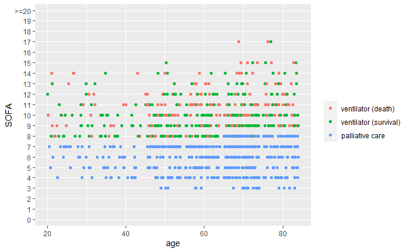

This plot represents the outcome of the allocation procedure as a function of the patient’s age (x-axis) and SOFA score (y-axis). The most efficient allocation system from a lives-saved perspective would have as many green dots as possible.

### Distribution of lives saved under a “sickest first” allocation system

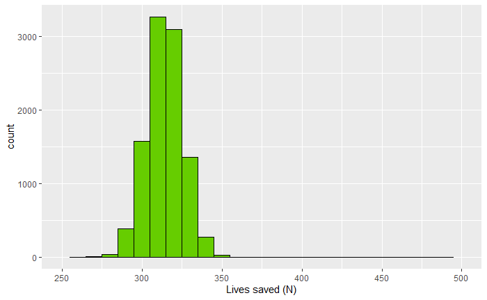

Distribution of lives saved during the allocation of 500 ventilators to 1,000 under a “sickest first” allocation system that priortizes patients with the highest SOFA score.

### Distribution of life-years saved under a “sickest first” allocation system

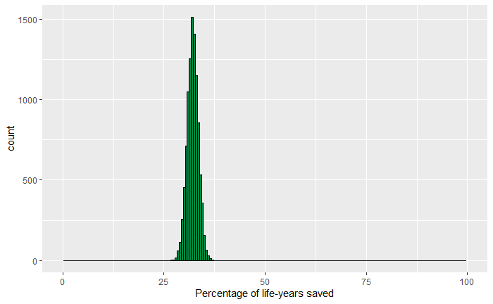

Distribution of life-years saved during the allocation of 500 ventilators to 1,000 under a “sickest first” allocation system that priortizes patients with the highest SOFA score.

## NY allocation

### Example of NY vent allocation plan

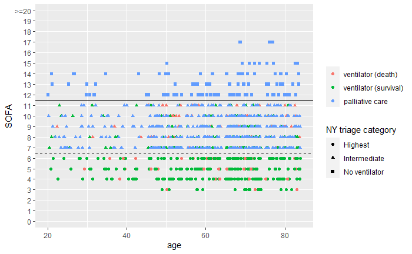

This plot represents the outcome of the allocation procedure as a function of the patient’s age (x-axis) and SOFA score (y-axis). The most efficient allocation system from a lives-saved perspective would have as many green dots as possible.

### Distribution of lives saved under New York (SOFA tiers) allocation plan

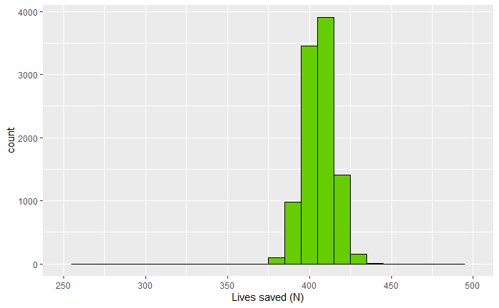

Distribution of lives-saved during the allocation of 500 ventilators to 1,000 under new york’s SOFA tiers + lottery allocation strategy.

### Distribution of life-years saved under New York (SOFA tiers) allocation plan

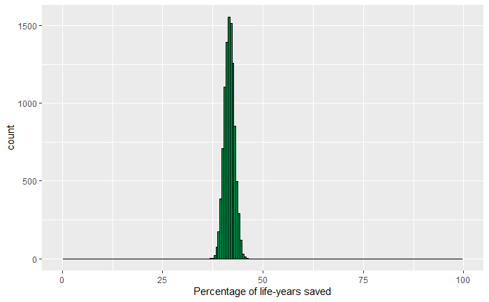

Distribution of life-years during the allocation of 500 ventilators to 1,000 under new york’s SOFA tiers + lottery allocation strategy.

## Maryland

This framework uses a combination of SOFA tiers and points for severe chronic disease, with age as a tiebreaker.

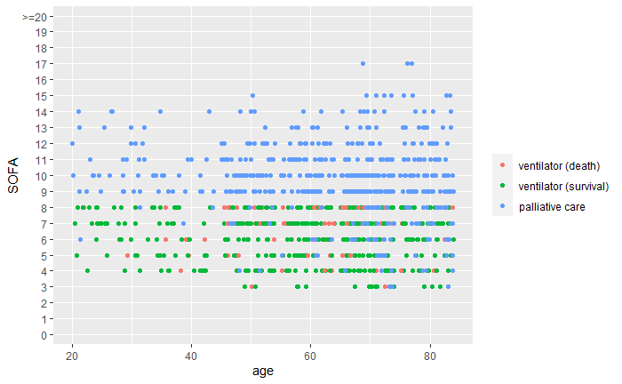

This plot represents the outcome of the allocation procedure as a function of the patient’s age (x-axis) and SOFA score (y-axis). The most efficient allocation system from a lives-saved perspective would have as many green dots as possible.

### Distribution of lives saved under Maryland Framework

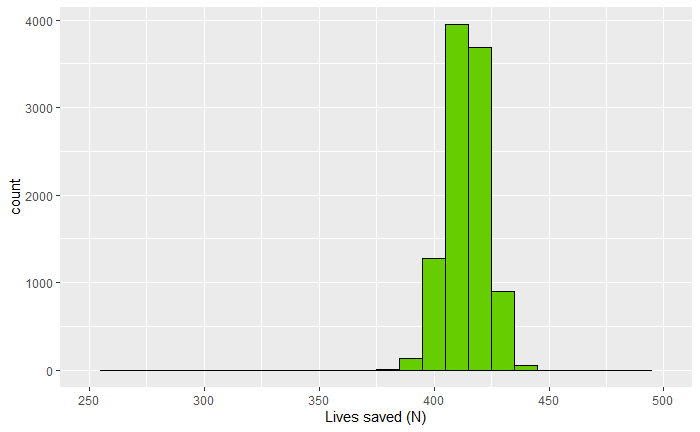

Distribution of lives saved during the allocation of 500 ventilators to 1,000 under maryland’s SOFA tiers+ chronic disaease point system

### Distribution of life-years saved under Maryland Framework

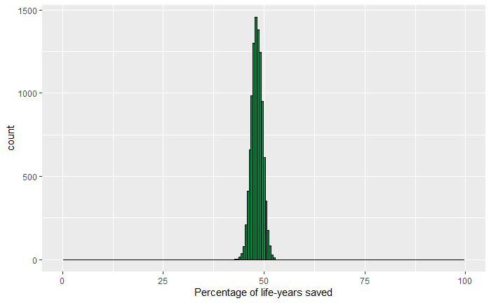

Distribution of life-years saved during the allocation of 500 ventilators to 1,000 under maryland’s SOFA tiers+ chronic disaease point system

## Pittsburgh

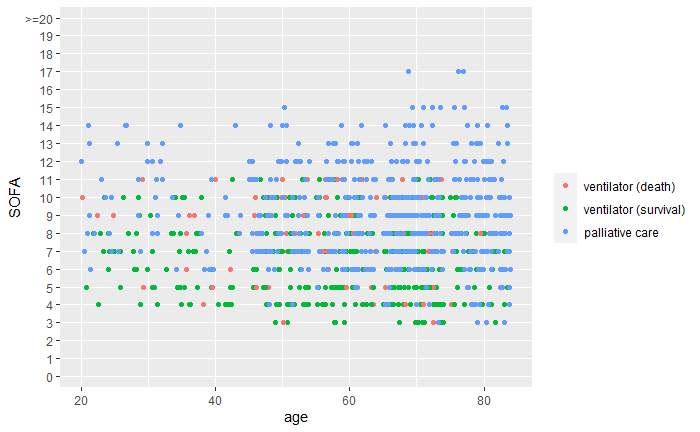

This plot represents the outcome of the allocation procedure as a function of the patient’s age (x-axis) and SOFA score (y-axis). The most efficient allocation system from a lives-saved perspective would have as many green dots as possible.

### Distribution of lives saved under Pittsburgh Framework

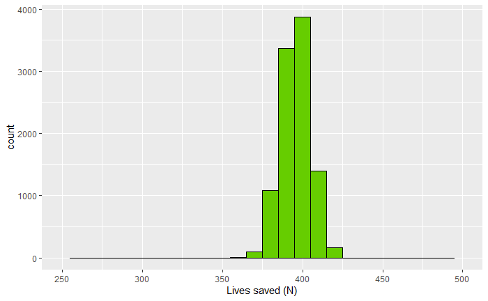

### Distribution of life-years saved under Pittsburgh Framework

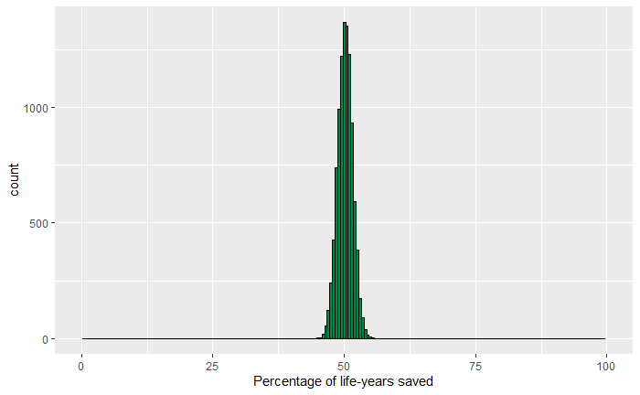

## Lottery allocation

In lottery allocation, ventilators are assigned randomly without regard to the patient’s age or probability of survival

### Example outcome under a random lottery allocation

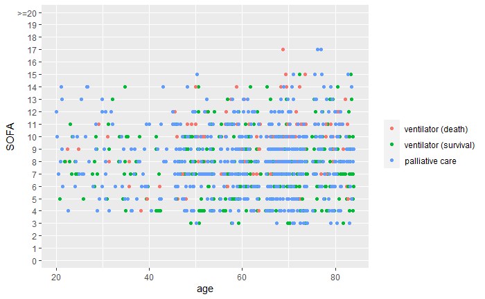

This plot represents the outcome of the allocation procedure as a function of the patient’s age (x-axis) and SOFA score (y-axis). The most efficient allocation system from a lives-saved perspective would have as many green dots as possible.

### Distribution of lives saved under a lottery allocation system

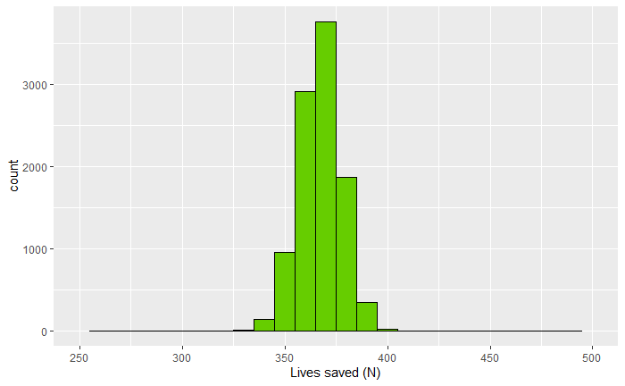

Distribution of lives-saved during the allocation of 500 ventilators to 1,000 under a lottery allocation system that assigns ventilators randomly

### Distribution of life-years saved under a lottery allocation system

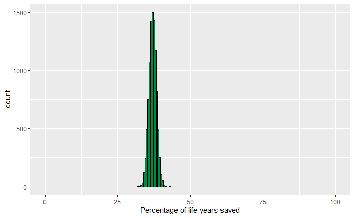

Distribution of the percentage of life-years saved during the allocation of 500 ventilators to 1,000 under a lottery allocation system that assigns ventilators randomly

## Youngest first

In youngest first allocation, the patients with the lowest age are assigned ventilators first. The severity of illness of the patients are ignored.

### Example of youngest-first allocation

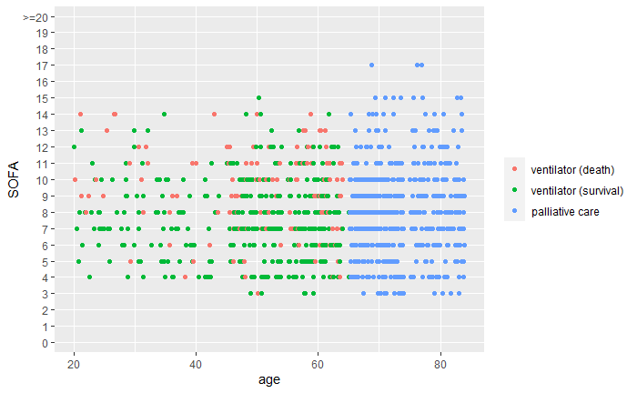

This plot represents the outcome of the allocation procedure as a function of the patient’s age (x-axis) and SOFA score (y-axis). The most efficient allocation system from a lives-saved perspective would have as many green dots as possible.

### Distribution of lives saved under youngest-first allocation

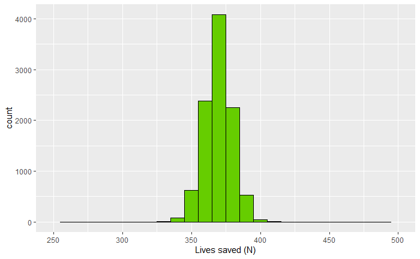

Distribution of lives-saved during the allocation of 500 ventilators to 1,000 under a youngest-first allocation policy.

### Distribution of life-years saved under youngest first allocation

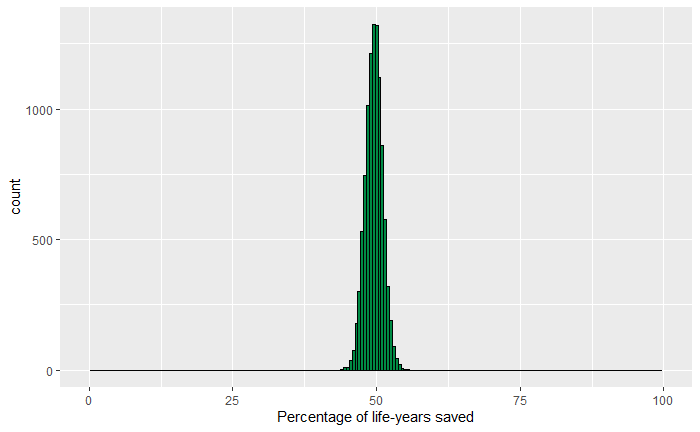

Distribution of life-years during the allocation of 500 ventilators to 1,000 under a youngest-first allocation policy.

## Maximizing Lives Saved

An allocation strategy focused on saving the most lives would use the SOFA variable as a continuous predictor, ranking patients so those with the lowest SOFA scores (higher means higher $P(death)$) get ventilators first

### Example of maximizing lives saved

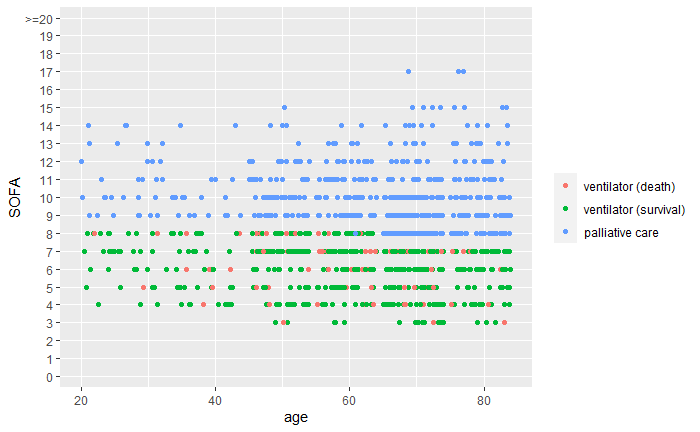

### Distribution of lives saved under a maximizing lives saved allocation strategy

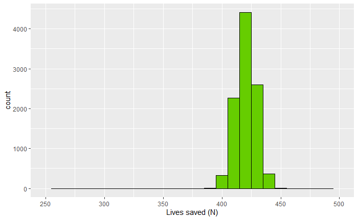

Distribution of lives during the allocation of 500 ventilators to 1,000 patients by lowest SOFA score

### Distribution of life-years saved under a maximizing lives saved strategy

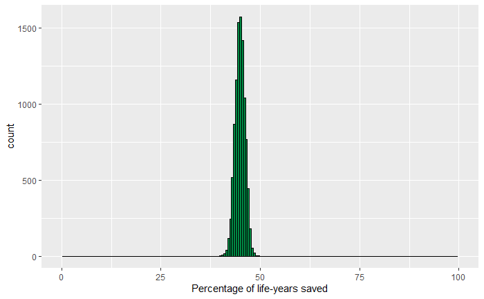

Distribution of life-years saved during the allocation of 500 ventilators to 1,000 patients by lowest SOFA score

## Maximizing Life-years gained

Maximizing life-years involves ranking patients by $P(survival)*(100-age)$. This quantity has a direct interpretation as the expected life-years to be saved by treating the patient with mechanical ventilation.

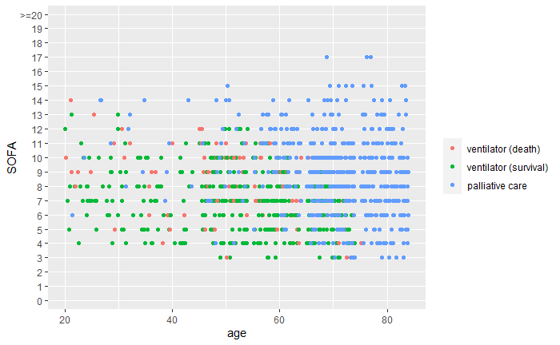

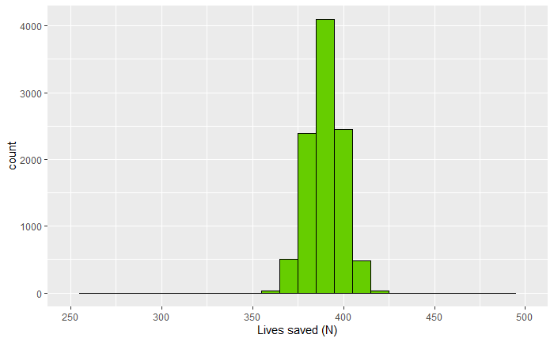

Distribution of lives saved during the allocation of 500 ventilators to 1,000 patients by $Priorty\space Score = P(Survival)*(100-age)$

### Distribution of life years saved under life-year maximization allocation

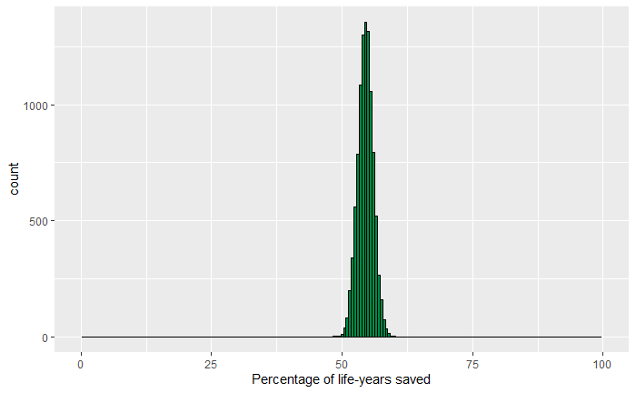

Distribution of life-years saved during the allocation of 500 ventilators to 1,000 patients by $Priorty\space Score = P(Survival)*(100-age)$

# Commented out single simulation plot

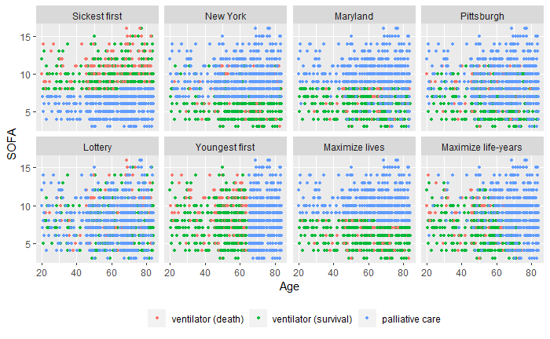

# Comparing allocation systems

## Distribution of lives-saved by system

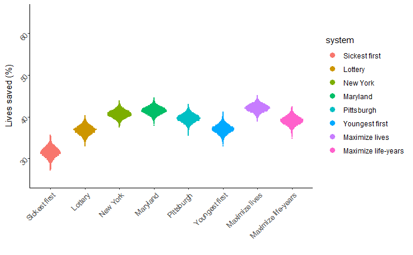

## Distribution of life-years saved by system

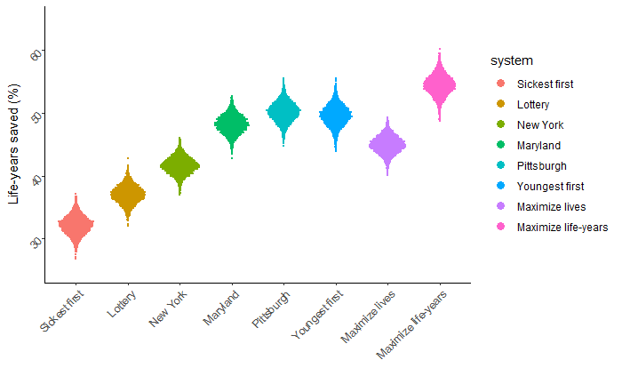

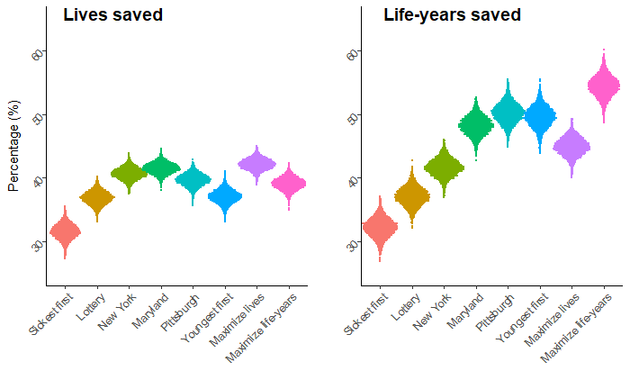

## Table of life and life years comparisons

| System | Lives Saved | Life-years Saved |
| --- | --- | --- |
| Sickest first | 315 (31) | 10219 (32) |
| Lottery | 368 (37) | 11784 (37) |
| New York | 407 (41) | 13243 (42) |
| Maryland | 415 (41) | 15342 (48) |
| Pittsburgh | 396 (40) | 15967 (50) |
| Youngest first | 370 (37) | 15773 (50) |
| Maximize lives | 421 (42) | 14292 (45) |
| Maximize life-years | 391 (39) | 17332 (54) |